# Loan prediction book v2

1. Make import of modules
2. import dataset and make a copy of it. This copy will be modified
3. Look at each feature column and handle missing values, outliers and convert it into appropriate datatype
4. Once data is clean, it is ready for exploration for relation with target
5. Pick the numerical and categorical features to use and convert it into all numerical matrix
6. Split into train and test and use various models
7. Validate model and tune parameters

```python
import pandas as pd
import numpy as np
import sklearn
import matplotlib.pyplot as plt
import seaborn as sns
%matplotlib inline
```

```python
raw_data = pd.read_csv('LoansTrainingSet.csv')
print raw_data.shape
print raw_data.columns
raw_data.head()
```

```
(256984, 19)
Index([u'Loan ID', u'Customer ID', u'Loan Status', u'Current Loan Amount',
       u'Term', u'Credit Score', u'Years in current job', u'Home Ownership',
       u'Annual Income', u'Purpose', u'Monthly Debt',
       u'Years of Credit History', u'Months since last delinquent',
       u'Number of Open Accounts', u'Number of Credit Problems',
       u'Current Credit Balance', u'Maximum Open Credit', u'Bankruptcies',
       u'Tax Liens'],
      dtype='object')
```

|  | Loan ID | Customer ID | Loan Status | Current Loan Amount | Term | Credit Score | Years in current job | Home Ownership | Annual Income | Purpose | Monthly Debt | Years of Credit History | Months since last delinquent | Number of Open Accounts | Number of Credit Problems | Current Credit Balance | Maximum Open Credit | Bankruptcies | Tax Liens |
| --- | --- | --- | --- | --- | --- | --- | --- | --- | --- | --- | --- | --- | --- | --- | --- | --- | --- | --- | --- |
| 0 | 000025bb-5694-4cff-b17d-192b1a98ba44 | 5ebc8bb1-5eb9-4404-b11b-a6eebc401a19 | Fully Paid | 11520 | Short Term | 741 | 10+ years | Home Mortgage | 33694 | Debt Consolidation | $584.03 | 12.3 | 41 | 10 | 0 | 6760 | 16056 | 0 | 0 |
| 1 | 00002c49-3a29-4bd4-8f67-c8f8fbc1048c | 927b388d-2e01-423f-a8dc-f7e42d668f46 | Fully Paid | 3441 | Short Term | 734 | 4 years | Home Mortgage | 42269 | other | $1,106.04 | 26.3 | NaN | 17 | 0 | 6262 | 19149 | 0 | 0 |
| 2 | 00002d89-27f3-409b-aa76-90834f359a65 | defce609-c631-447d-aad6-1270615e89c4 | Fully Paid | 21029 | Short Term | 747 | 10+ years | Home Mortgage | 90126 | Debt Consolidation | $1,321.85 | 28.8 | NaN | 5 | 0 | 20967 | 28335 | 0 | 0 |
| 3 | 00005222-b4d8-45a4-ad8c-186057e24233 | 070bcecb-aae7-4485-a26a-e0403e7bb6c5 | Fully Paid | 18743 | Short Term | 747 | 10+ years | Own Home | 38072 | Debt Consolidation | $751.92 | 26.2 | NaN | 9 | 0 | 22529 | 43915 | 0 | 0 |
| 4 | 0000757f-a121-41ed-b17b-162e76647c1f | dde79588-12f0-4811-bab0-e2b07f633fcd | Fully Paid | 11731 | Short Term | 746 | 4 years | Rent | 50025 | Debt Consolidation | $355.18 | 11.5 | NaN | 12 | 0 | 17391 | 37081 | 0 | 0 |

```python
# Make a copy of the data
df = raw_data.copy()
```

To make useful operations on data, we need the data to be in the right format. Let's look at the various features and their datatypes and convert them into a more useful form if possible

```python
df.dtypes
```

```
Loan ID                          object
Customer ID                      object
Loan Status                      object
Current Loan Amount               int64
Term                             object
Credit Score                    float64
Years in current job             object
Home Ownership                   object
Annual Income                   float64
Purpose                          object
Monthly Debt                     object
Years of Credit History         float64
Months since last delinquent    float64
Number of Open Accounts           int64
Number of Credit Problems         int64
Current Credit Balance            int64
Maximum Open Credit              object
Bankruptcies                    float64
Tax Liens                       float64
dtype: object
```

Monthly debt is a column that should be a float and not a string Similar is the case of Maximum Open Credit which should be a number rather than a string

```python
a = df['Monthly Debt']
df['Monthly Debt'] = a.str.extract(r'\$([\.\,0-9]*)').str.replace(',','').astype('float64')
print df['Monthly Debt'].dtype
```

```
float64
```

```python
a = df['Maximum Open Credit']
a = a.astype('str')
l = a[~a.str.isdigit()].index
a.ix[l] = np.nan
df['Maximum Open Credit'] = a.astype('float64')
print df['Maximum Open Credit'].dtype
```

```
float64
```

```python
a = df['Current Loan Amount']
a = a.astype('float64')
l = a[a==99999999].index
a.ix[l]=np.nan
df['Current Loan Amount'] = a
print df['Current Loan Amount'].dtype
```

```
float64
```

```python
# Let's look at feature #1: Loan ID
feature = 'Loan ID'
print df['Loan ID'].dtype

# Since the datatype is object(string), we will look at the top 5 and bottom 5 most common values
print df['Loan ID'].value_counts().head(5)
print df['Loan ID'].value_counts().tail(5)
```

```
object
de5e38c0-5e62-46c1-87f0-e412dc59140c    4
a71fc37a-2be4-4740-abad-a8084f4c4310    4
f14d2349-dd5a-4dfe-a595-912483a27a0d    4
b624940f-da82-410b-b885-77d92c2e4f0c    4
9fa4e052-1e55-42d8-bf98-e8e387f02b97    4
dtype: int64
3d048258-1b6a-4453-9870-211d6968a03c    1
92f35716-a1aa-4677-ae32-4e2386a56362    1
0721eaed-7aa1-4ebe-92d1-6506322aaddb    1
9bec31f6-3526-43cf-aea7-98daa060efb7    1
5b11b29a-700e-42fa-9992-14067457ec62    1
dtype: int64
```

```python
# Since Loan ID is an identifier of the loan issued we need to remove duplicates
# Let's look at the rows with duplicate Loan IDs

a = df['Loan ID'].value_counts()
a[a>1].index
repeat_df = df[df['Loan ID'].isin(a[a>1].index)]
unique_df = df.ix[list(set(df.index) - set(repeat_df.index))]

# We have a percentage of duplicates of
print 'percentage of repeated rows is %d '%(100*len(repeat_df)/(len(repeat_df)+len(unique_df)))
print '# of unique observations is %d '%(len(unique_df))
print '# of duplicated observations is %d '%(len(repeat_df))
print '# of observations in the duplicated set is %d'%(len(repeat_df.groupby('Loan ID').size()))
print '# of observations in final dataset is %d' %(len(unique_df)+len(repeat_df.groupby('Loan ID').size()))
```

```
percentage of repeated rows is 31
# of unique observations is 176520
# of duplicated observations is 80464
# of observations in the duplicated set is 39180
# of observations in final dataset is 215700
```

Figure out a way to get rid of the duplicates in the repeated_df and append that to the unique_df to get back df

```python
#unique_df.head(10)
#len(repeat_df.groupby('Loan ID').size())
#repeat_df.notnull().all()
cols = ['Loan ID','Credit Score','Annual Income','Monthly Debt','Current Loan Amount',
        'Months since last delinquent','Maximum Open Credit','Bankruptcies','Tax Liens',
        'Number of Open Accounts','Years of Credit History','Current Credit Balance',
        'Number of Credit Problems']

#repeat_df[cols].groupby('Loan ID').mean().head(20)

#repeat_df[cols].head(10).groupby('Loan ID').mean()
#repeat_df = repeat_df.drop_duplicates()
#repeat_df.drop_duplicates().groupby('Loan ID').mean()

#repeat_df[cols].head(10)
#g = repeat_df.groupby('Loan ID')
rem_cols = list(set(repeat_df.columns)-set(cols))+['Loan ID']
rem_cols
p = repeat_df[rem_cols]
#p.head()
#len(p.drop_duplicates().groupby('Loan ID').size().order(ascending=False))
#p[p['Loan ID'].isin(q[q>1].index)]
p = p.drop_duplicates()
p.head()
```

|  | Term | Home Ownership | Customer ID | Years in current job | Loan Status | Purpose | Loan ID |
| --- | --- | --- | --- | --- | --- | --- | --- |
| 6 | Long Term | Rent | e49c1a82-a0f7-45e8-9f46-2f75c43f9fbc | 6 years | Charged Off | Business Loan | 0000afa6-8902-4f8f-b870-25a8fdad0aeb |
| 12 | Short Term | Own Home | afbc2fa3-3bad-4d48-b691-829aed78bad5 | < 1 year | Charged Off | Debt Consolidation | 00029f9f-0cc5-4d4e-aabc-ea4a7fe74e12 |
| 18 | Short Term | Home Mortgage | 28eb75ac-6a09-4057-b73f-726c72ebf933 | 6 years | Charged Off | Debt Consolidation | 00035328-2636-4390-8322-5841de482d2b |
| 20 | Long Term | Home Mortgage | 727bb429-dfa1-41c4-a347-23230e23949f | 3 years | Charged Off | Debt Consolidation | 00038a08-f058-4add-a8ed-497b91672a9e |
| 31 | Short Term | Home Mortgage | c1a7ba66-9f36-4f5c-86cd-1aa7ad68b954 | 3 years | Charged Off | Debt Consolidation | 0006572c-9567-484d-b49b-bfe06536aa96 |

```python
q = repeat_df[cols].groupby('Loan ID').mean()
q = q.reset_index(0)
q.head()
clean_df = p.merge(q,on='Loan ID')
len(clean_df)
```

```
39180
```

```python
data = unique_df.append(clean_df,ignore_index=True)
data = data[raw_data.columns]
print data.shape
data.iloc[2:8,:]
```

```
(215700, 19)
```

|  | Loan ID | Customer ID | Loan Status | Current Loan Amount | Term | Credit Score | Years in current job | Home Ownership | Annual Income | Purpose | Monthly Debt | Years of Credit History | Months since last delinquent | Number of Open Accounts | Number of Credit Problems | Current Credit Balance | Maximum Open Credit | Bankruptcies | Tax Liens |
| --- | --- | --- | --- | --- | --- | --- | --- | --- | --- | --- | --- | --- | --- | --- | --- | --- | --- | --- | --- |
| 2 | 00002d89-27f3-409b-aa76-90834f359a65 | defce609-c631-447d-aad6-1270615e89c4 | Fully Paid | 21029 | Short Term | 747 | 10+ years | Home Mortgage | 90126 | Debt Consolidation | 1321.85 | 28.8 | NaN | 5 | 0 | 20967 | 28335 | 0 | 0 |
| 3 | 00005222-b4d8-45a4-ad8c-186057e24233 | 070bcecb-aae7-4485-a26a-e0403e7bb6c5 | Fully Paid | 18743 | Short Term | 747 | 10+ years | Own Home | 38072 | Debt Consolidation | 751.92 | 26.2 | NaN | 9 | 0 | 22529 | 43915 | 0 | 0 |
| 4 | 0000757f-a121-41ed-b17b-162e76647c1f | dde79588-12f0-4811-bab0-e2b07f633fcd | Fully Paid | 11731 | Short Term | 746 | 4 years | Rent | 50025 | Debt Consolidation | 355.18 | 11.5 | NaN | 12 | 0 | 17391 | 37081 | 0 | 0 |
| 5 | 0000a149-b055-4a57-b762-280783ccc25e | 62ddc017-7023-4ba7-af23-1a7cd16c1ce5 | Fully Paid | 10208 | Short Term | 716 | 10+ years | Rent | 41853 | Business Loan | 561.52 | 13.2 | NaN | 4 | 1 | 2289 | 4671 | 1 | 0 |
| 6 | 00011dfc-31c1-4178-932a-fbeb3f341efb | ef6e098c-6c83-4752-8d00-ff793e476b8c | Fully Paid | 10036 | Short Term | NaN | 5 years | Rent | NaN | Debt Consolidation | 386.36 | 17.7 | NaN | 7 | 0 | 11970 | 16579 | 0 | 0 |
| 7 | 0001cb86-af28-4011-bb86-183786e473ae | 4aae67bb-d54b-41ae-8bce-1d62022ed8dd | Fully Paid | 2036 | Short Term | 733 | n/a | Home Mortgage | 55985 | Debt Consolidation | 741.79 | 19.8 | 29 | 7 | 0 | 10926 | 15676 | 0 | 0 |

```python
# data contains the cleaned unique dataset on which we can carry out feature analysis
df = data.copy()
```

```python
#df.head()
feature_list = ['Term','Home Ownership', 'Purpose','Years of Credit History']
X = df[feature_list]
X['Home Ownership'] = X['Home Ownership'].str.replace('HaveMortgage','Home Mortgage')
X['Purpose'] = X['Purpose'].str.replace('other','Other')
y = np.where(df['Loan Status']=='Charged Off',1,0)
```

```python
# Let's look at feature #2: Customer ID
feature = 'Customer ID'
print df[feature].dtype

# Since the datatype is object(string), we will look at the top 5 and bottom 5 most common values
print df[feature].value_counts().head(5)
print df[feature].value_counts().tail(5)
```

```
object
6b7bba75-948a-4fca-b3bd-3ef0de0a390c    1
cfdcf4d5-d413-4c25-a403-964ddbe72e12    1
f2866c4f-f9fd-4cfe-9674-a15eedfa41a1    1
9001fa5e-cba9-4684-a818-451de5b5066e    1
d59541f4-8325-40f8-98f5-3905f1a0f6a7    1
dtype: int64
3cd285b9-92d2-45b9-b76d-7fa55df41f72    1
8c186bd7-37de-461c-96f5-d85c716d6415    1
10a4b17d-408c-4ee6-94b7-ee2e95a71dcd    1
b7eb6966-3047-4a2b-8da4-3648609f35d0    1
b5f8a57b-39fe-45f6-8d2e-5f4cde04581b    1
dtype: int64
```

```python
# Let's look at feature #3: Loan Status
feature = 'Loan Status'
print df[feature].dtype

# Since the datatype is object(string), we will look at the top 5 and bottom 5 most common values
print df[feature].value_counts().head(5)
print df[feature].value_counts().tail(5)
```

```
object
Fully Paid     176191
Charged Off     39509
dtype: int64
Fully Paid     176191
Charged Off     39509
dtype: int64
```

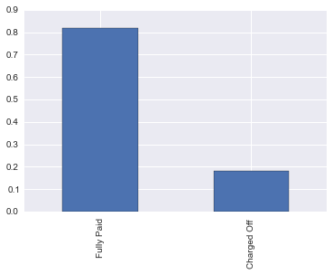

```python
a = df['Loan Status'].value_counts()
a.div(sum(a)).plot(kind='bar')
```

The above bar graph shows how there is an inherent class imbalance among the records i.e. we have 80% observations where loan is paid and just 20% records where loan is defaulted. We have to be aware of this since the classifier will be biased towards predicting that the loan will be repaid.

```python
# Let's look at feature #4: Current Loan Amount
feature = 'Current Loan Amount'
print df[feature].dtype
print df[feature].describe()
# Since the datatype is object(string), we will look at the top 5 and bottom 5 most common values
print df[feature].value_counts().head(5)
print df[feature].value_counts().tail(5)
```

```
float64
count    180490.000000
mean      13806.593588
std        8215.180445
min         505.000000
25%        7604.000000
50%       11968.000000
75%       19055.750000
max       41000.000000
Name: Current Loan Amount, dtype: float64
9793     50
9820     48
10192    43
5920     43
10025    42
dtype: int64
22359.0    1
22358.0    1
22355.0    1
22353.0    1
17970.5    1
dtype: int64
```

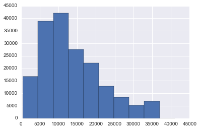

```python
df['Current Loan Amount'].hist()
```

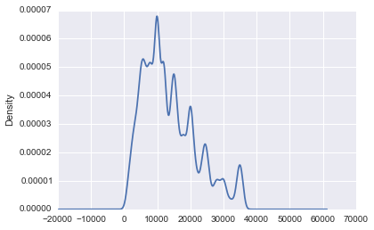

```python
#np.log(df['Current Loan Amount']).hist()
#df['Current Loan Amount'].hist(by=df['Loan Status'])
df['Current Loan Amount'].plot(kind='kde')#,by=df['Loan Status'])
```

```python
# We have a lot of NAs in this feature, lets see if it is random in occurence or has a pattern to it
a = df['Current Loan Amount']
#print 'percentage of missing values is %f'% (100.0*sum(a.isnull())/len(a))
#sns.FacetGrid(hue = 'Loan Status',data=df).map(sns.kdeplot,'Current Loan Amount')
#plt.legend()
#df.groupby('Loan Status')['Current Loan Amount'].apply(lambda x: 1.0*sum(x.isnull())/len(x))

#plt.hist(df['Current Loan Amount'].dropna())

# this shows that if current loan amount is absent then with high probability the loan has been fully paid,
#this looks like a useful feature which we will create
f_CLA_present = np.where(df['Current Loan Amount'].isnull(),0,1)
```

[output not shown]

```
object
Short Term    166523
Long Term      49177
dtype: int64
Short Term    166523
Long Term      49177
dtype: int64
```

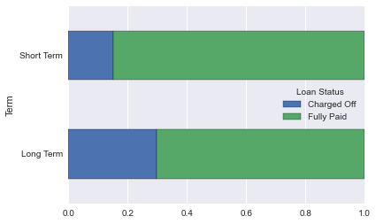

```python
# Let's look at feature #5: Term
feature = 'Term'
print df[feature].dtype

# Since the datatype is object(string), we will look at the top 5 and bottom 5 most common values
print df[feature].value_counts().head(5)
print df[feature].value_counts().tail(5)

df.groupby(['Loan Status','Term']).size().unstack().apply(lambda x: x/np.sum(x),axis=0).T.plot(kind='barh',stacked=True)
```

```python
# Let's look at feature #6: Credit Score
feature = 'Credit Score'
print df[feature].dtype

# Since the datatype is object(string), we will look at the top 5 and bottom 5 most common values
print df[feature].value_counts().head(5)
print df[feature].value_counts().tail(5)

#a = df['Credit Score']
#a = df[a<1000]['Credit Score']
#plt.hist(df[feature].dropna())
#sns.FacetGrid(hue = 'Loan Status',data=df).map(plt.hist,'Credit Score')
#sns.FacetGrid(hue = df['Loan Status']).map(plt.hist,a)
#plt.hist(a,c=df['Loan Status])
#plt.legend()

df[df['Credit Score']<1000][['Credit Score','Loan Status']].dropna().groupby('Loan Status').describe()#apply(lambda x:plt.hist(x))
# Credit score above 850 leads to charged off loans and we will make this a feature
# For credit scores below 850 lower scores are seen in charged off loans so we can scale these values for
# normalization
f_CS_Valid = np.where(df['Credit Score']<850,1,0)
df.ix[df['Credit Score']>850,'Credit Score'] = np.nan
df['Credit Score'] = df['Credit Score'].fillna(585)

#How to fill up the nan values of credit score? maybe look at relations with income etc.
df.groupby('Loan Status')['Credit Score'].apply(lambda x:1.0*sum(x.isnull())/len(x))
```

```
float64
747    5406
746    5183
740    5078
741    5039
742    4830
dtype: int64
590    14
588    14
591    12
585    12
589     7
dtype: int64
```

[output not shown]

```python
# Let's look at feature #6: Years in Current job
feature = 'Years in current job'
print df[feature].dtype

# Since the datatype is object(string), we will look at the top 5 and bottom 5 most common values
print df[feature].value_counts().head(5)
print df[feature].value_counts().tail(5)
```

```
object
10+ years    66711
2 years      19831
< 1 year     17544
3 years      17428
5 years      14987
dtype: int64
6 years    12230
7 years    11713
8 years    10232
n/a         8990
9 years     8272
dtype: int64
```

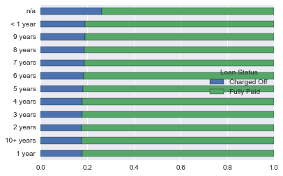

```python
status_grp = df.groupby('Loan Status')
status_grp[feature].value_counts().unstack().apply(lambda x: x/np.sum(x),axis=0).T.plot(kind='barh',stacked = True)

# doesn't look a very promising feature since very little distinction, except NA or not
```

```python
job_grp = df.groupby('Years in current job')
job_grp['Credit Score'].describe().unstack()
```

| Years in current job | count | mean | std | min | 25% | 50% | 75% | max |
| --- | --- | --- | --- | --- | --- | --- | --- | --- |
| 1 year | 10216 | 724.583203 | 25.289663 | 586 | 714 | 733 | 742 | 751 |
| 10+ years | 48621 | 723.495527 | 26.493765 | 585 | 714 | 732 | 742 | 751 |
| 2 years | 14550 | 724.286942 | 25.830923 | 585 | 714 | 733 | 742 | 751 |
| 3 years | 12736 | 724.239714 | 25.949604 | 585 | 714 | 733 | 742 | 751 |
| 4 years | 9832 | 723.980980 | 25.885929 | 587 | 714 | 732 | 742 | 751 |
| 5 years | 10814 | 724.562049 | 25.818243 | 586 | 715 | 733 | 743 | 751 |
| 6 years | 8908 | 724.156713 | 26.242873 | 586 | 714 | 733 | 742 | 751 |
| 7 years | 8459 | 723.181818 | 26.643634 | 587 | 713 | 732 | 742 | 751 |
| 8 years | 7410 | 723.136167 | 26.279316 | 585 | 713 | 731 | 742 | 751 |
| 9 years | 6025 | 722.996017 | 26.716087 | 585 | 713 | 732 | 742 | 751 |
| < 1 year | 12717 | 724.613509 | 25.340409 | 586 | 714 | 733 | 743 | 751 |
| n/a | 6481 | 723.784755 | 25.412792 | 590 | 713 | 732 | 742 | 751 |

```python
# Let's look at feature #7: Home Ownership
feature = 'Home Ownership'
print df[feature].dtype

# Since the datatype is object(string), we will look at the top 5 and bottom 5 most common values
print df[feature].value_counts().head(5)
print df[feature].value_counts().tail(5)

df[feature] = df[feature].astype('category')
```

```
object
Home Mortgage    106492
Rent              89619
Own Home          19094
HaveMortgage        495
dtype: int64
Home Mortgage    106492
Rent              89619
Own Home          19094
HaveMortgage        495
dtype: int64
```

```python
a = df['Home Ownership']
a[a=='HaveMortgage']= 'Home Mortgage'
a = a.cat.remove_unused_categories()
df['Home Ownership'] = a
```

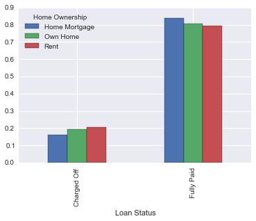

```python
a = df.groupby(['Loan Status','Home Ownership']).size().unstack(1)
a = a.apply(lambda x: x/np.sum(x),axis=0)#plot(kind='bar',stacked=True)
a.plot(kind='bar')
#plt.legend(loc = 'best')
```

```
{'boxes': [<matplotlib.lines.Line2D at 0x308c6a58>,
 'caps': [<matplotlib.lines.Line2D at 0x22123828>,
 'fliers': [<matplotlib.lines.Line2D at 0x2212f8d0>,
 'means': [],
 'medians': [<matplotlib.lines.Line2D at 0x2212f358>,
 'whiskers': [<matplotlib.lines.Line2D at 0x308c6cc0>,
```

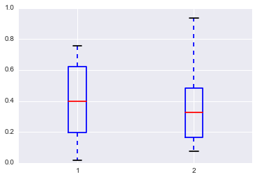

```python
plt.boxplot(np.random.rand(10,2),meanline=True,showfliers=True)
```

```python
from sklearn.preprocessing import LabelEncoder
cat2int = LabelEncoder()
cat2int.fit_transform(A['Purpose'])
```

```python
a = pd.DataFrame({'one':[0,1,1,0,1],'two':[0,3,2,1,2]})

from sklearn.preprocessing import OneHotEncoder
enc = OneHotEncoder(sparse=False)
enc.fit_transform(a)
```

```python
from sklearn import pipeline
p = pipeline.Pipeline([('lab_enc',LabelEncoder()),('onehot_enc',OneHotEncoder(sparse=False))])
#p.named_steps
p.fit_transform(a)
```

```python
a = pd.DataFrame({'one':['n','y','y','n','y'],'two':['z','th','tw','o','tw']})
b = a.copy()
print a
print '\n'
from sklearn.preprocessing import LabelEncoder
lab_enc = LabelEncoder()
for col in a.columns:
    b[col] = lab_enc.fit_transform(a[col])
print b
print '\n'
from sklearn.preprocessing import OneHotEncoder
onehot_enc = OneHotEncoder(sparse=False)
c = onehot_enc.fit_transform(b)
print c
```

[output not shown]

```python
#c = pd.DataFrame(np.random.randint(low=1,high=10,size=[5,2]),columns=['col1','col2'])
c = pd.DataFrame(np.random.rand(5,2),columns=['col1','col2'])
print c
print '\n'

from sklearn.preprocessing import Normalizer
s_scale = Normalizer()
d = s_scale.fit_transform(c)
print d
print '\n'

from sklearn.preprocessing import Binarizer
s_scale = Binarizer(threshold = 0.3)
e = s_scale.fit_transform(c)
print e
print '\n'
```

[output not shown]

```python
from sklearn.feature_extraction import DictVectorizer
vec = DictVectorizer()
vec.fit_transform(X)
```